# Consolidated_Plots_Code

```r
library(ggplot2)
library(tidyverse)
diamonds<-read_csv("diamonds4.csv")
#Check Data Loaded Properly:
head(diamonds)
```

| carat | clarity | color | cut | price |
| --- | --- | --- | --- | --- |
| 0.24 | VVS2 | G | Very Good | 379 |
| 0.40 | VS2 | H | Very Good | 605 |
| 3.35 | IF | F | Good | 56151 |
| 0.61 | VS2 | G | Ideal | 1947 |
| 0.40 | VVS1 | J | Ideal | 684 |
| 0.50 | VS1 | E | Very Good | 1553 |

```r
NA
NA
```

Get size/shape of Data:

```r
nrow(diamonds)
```

```
[1] 1214
```

```r
ncol(diamonds)
```

```
[1] 5
```

```r
dim(diamonds)
```

```
[1] 1214    5
```

5 variables, and 1,214 rows

Checking for NA’s:

```r
(diamonds[!complete.cases(diamonds),])
```

| carat | clarity | color | cut | price |
| --- | --- | --- | --- | --- |

```r
(diamonds[complete.cases(diamonds),])
```

| carat | clarity | color | cut | price |
| --- | --- | --- | --- | --- |
| 0.24 | VVS2 | G | Very Good | 379 |
| 0.40 | VS2 | H | Very Good | 605 |
| 3.35 | IF | F | Good | 56151 |
| 0.61 | VS2 | G | Ideal | 1947 |
| 0.40 | VVS1 | J | Ideal | 684 |
| 0.50 | VS1 | E | Very Good | 1553 |
| 1.76 | VS1 | D | Ideal | 24451 |
| 1.02 | SI1 | J | Very Good | 3958 |
| 0.70 | SI1 | F | Very Good | 2091 |
| 1.01 | VS1 | H | Very Good | 6079 |

[output cut: 990 more lines]

No Na’s in data-nice.

Check for levels:

```r
levels(diamonds$cut)
```

```r
levels(diamonds$color)
```

```r
levels(diamonds$clarity)
```

No levels. We’ll need to add some factors to get data in order that matches the website, since alphabetical won’t work for all data:

```r
diamonds<- diamonds%>%
  mutate(cut = cut%>%
           fct_relevel(c("Good","Very Good","Ideal","Astor Ideal")))

diamonds<- diamonds%>%
  mutate(clarity = clarity%>%
           fct_relevel(c("SI2","SI1","VS2","VS1", "VVS2", "VVS1", "IF", "FL")))

#Since R defaults to alphabetical order, we don't need to neccessarily add factors here, but doing so to flip order the same as above

diamonds<- diamonds%>%
  mutate(color = color%>%
           fct_relevel(c("J","I","H","G", "F", "E", "D")))

#Check new levels:

levels(diamonds$cut)
```

```
[1] "Good"        "Very Good"   "Ideal"       "Astor Ideal"
```

```r
levels(diamonds$color)
```

```
[1] "J" "I" "H" "G" "F" "E" "D"
```

```r
levels(diamonds$clarity)
```

```
[1] "SI2"  "SI1"  "VS2"  "VS1"  "VVS2" "VVS1" "IF"   "FL"
```

To visual distributions of different parameters:

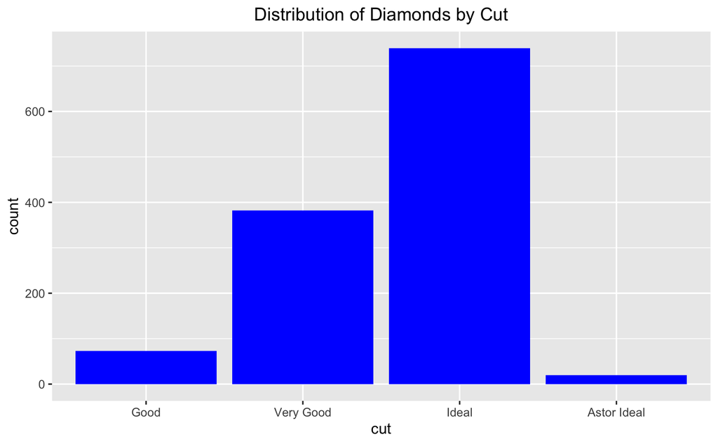

```r
ggplot(diamonds, aes(x=cut))+
  geom_bar(fill="blue")+
  theme(plot.title = element_text(hjust = .5))+
  labs(title = "Distribution of Diamonds by Cut")
```

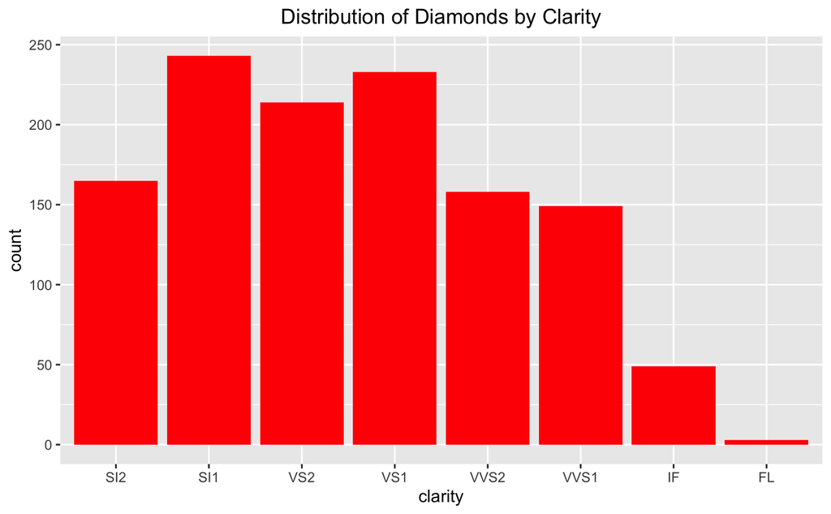

```r
ggplot(diamonds, aes(x=clarity))+
  geom_bar(fill="red")+
  theme(plot.title = element_text(hjust = .5))+
  labs(title = "Distribution of Diamonds by Clarity")
```

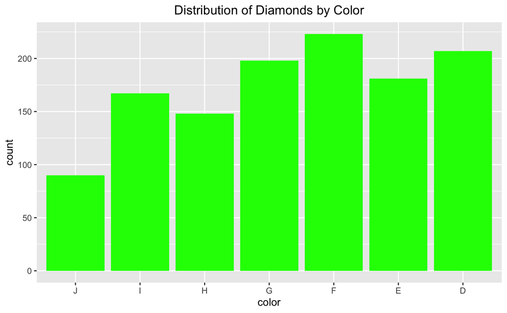

```r
ggplot(diamonds, aes(x=color))+
  geom_bar(fill="green")+
  theme(plot.title = element_text(hjust = .5))+
  labs(title = "Distribution of Diamonds by Color")
```

Scatter plot of Price vs Carat:

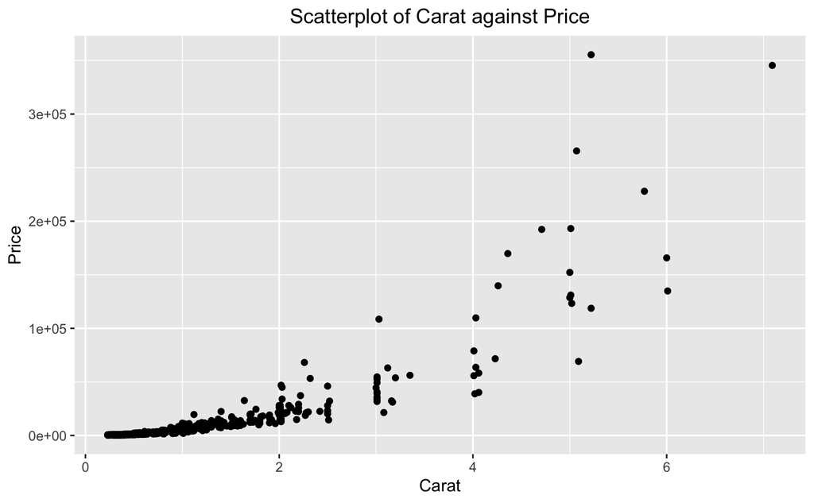

```r
ggplot(data = diamonds, aes(x = carat, y = price)) +
  geom_point()+
  theme(plot.title = element_text(hjust = .5))+
  labs(title = "Scatterplot of Carat against Price",
       x = "Carat",
         y = "Price")
```

Scatter plot of Price vs Carat with all parameters added:

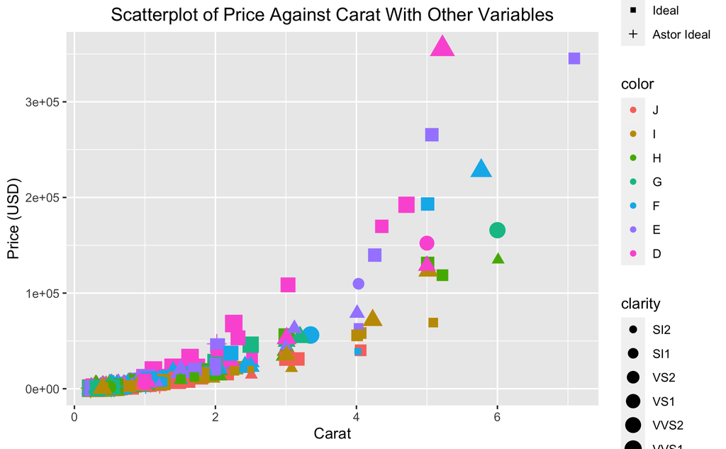

```r
ggplot(data = diamonds, aes(x = carat, y = price, color = color, size = clarity, shape = cut)) +
  geom_point()+
  theme(plot.title = element_text(hjust = .5))+
  labs(title = "Scatterplot of Price Against Carat With Other Variables",
       x = "Carat",
       y = "Price (USD)")
```

Very Messy and not particularly useful, so let’s break it down into indvidual variables:

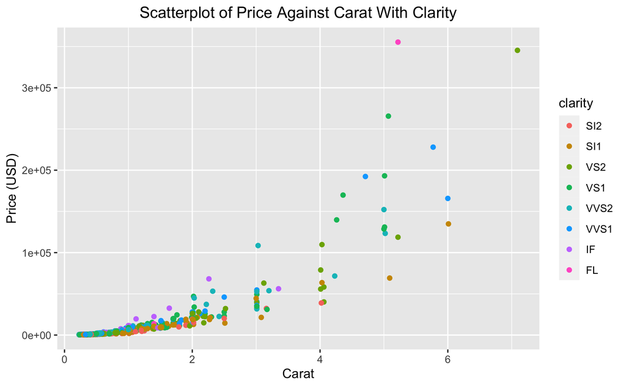

```r
ggplot(data = diamonds, aes(x = carat, y = price, color = clarity))+
  geom_point()+
  theme(plot.title = element_text(hjust = .5))+
  labs(title = "Scatterplot of Price Against Carat With Clarity",
       x = "Carat",
       y = "Price (USD)")
```

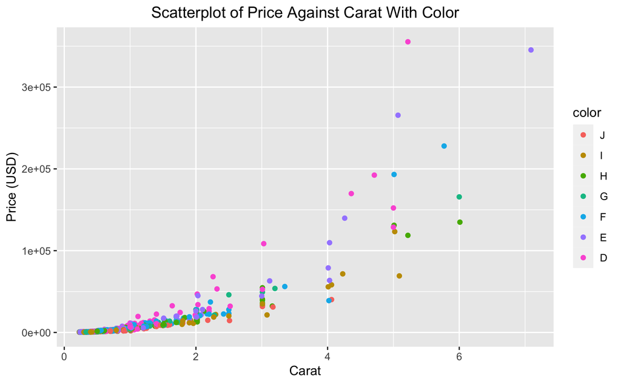

```r
ggplot(data = diamonds, aes(x = carat, y = price, color = color)) +
  geom_point()+
  theme(plot.title = element_text(hjust = .5))+
  labs(title = "Scatterplot of Price Against Carat With Color",
       x = "Carat",
       y = "Price (USD)")
```

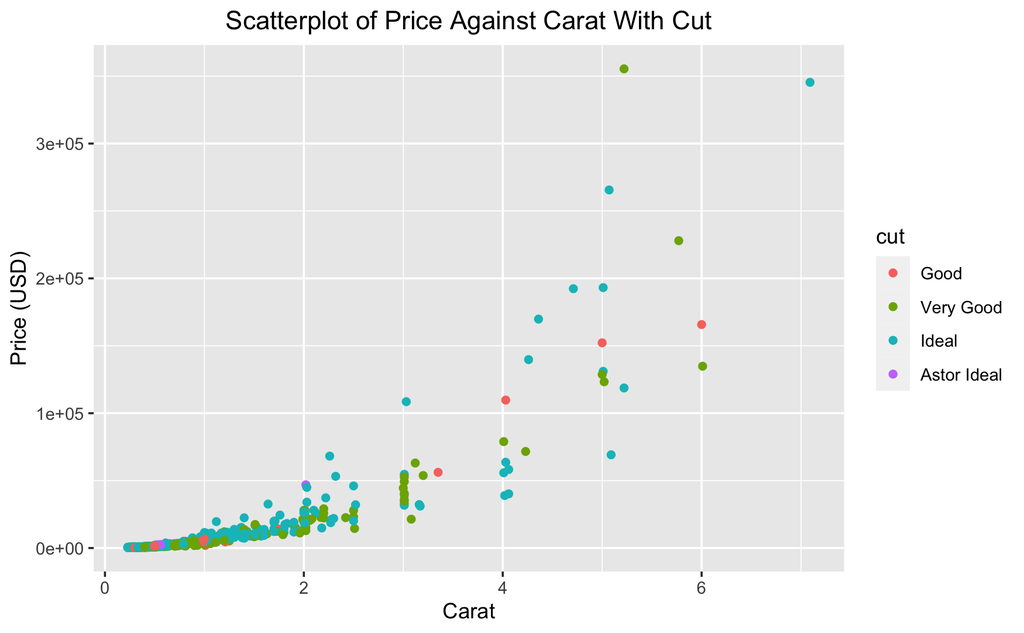

```r
ggplot(data = diamonds, aes(x = carat, y = price, color = cut)) +
  geom_point()+
  theme(plot.title = element_text(hjust = .5))+
  labs(title = "Scatterplot of Price Against Carat With Cut",
                     x = "Carat",
                     y = "Price (USD)")
```

Website Claims order of importance is: Cut, color, carat, clarity

First: create new column “price/carat” to control for carat size as we explore how other attributes affect price

```r
diamonds<-diamonds%>%
  mutate(PricePerCarat = price/carat)
```

Get grouped means of price per carat for each attribute:

```r
ClarityVSPricePerCarat<-diamonds%>%
  group_by(clarity)%>%
  summarize(meanPrice=mean(PricePerCarat))

ColorVSPricePerCarat<-diamonds%>%
  group_by(color)%>%
  summarize(meanPrice=mean(PricePerCarat))

CutVSPricePerCarat<-diamonds%>%
  group_by(cut)%>%
  summarize(meanPrice=mean(PricePerCarat))
```

Plots of grouped Means:

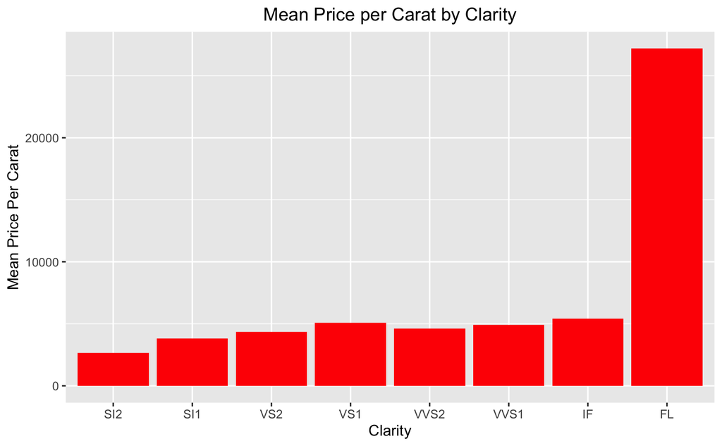

```r
ggplot(ClarityVSPricePerCarat, aes(x=clarity, y=meanPrice))+
  geom_bar(stat="identity", fill = "red")+
  theme(plot.title = element_text(hjust = .5))+
  labs(title = "Mean Price per Carat by Clarity",
       x = "Clarity",
       y = "Mean Price Per Carat")
```

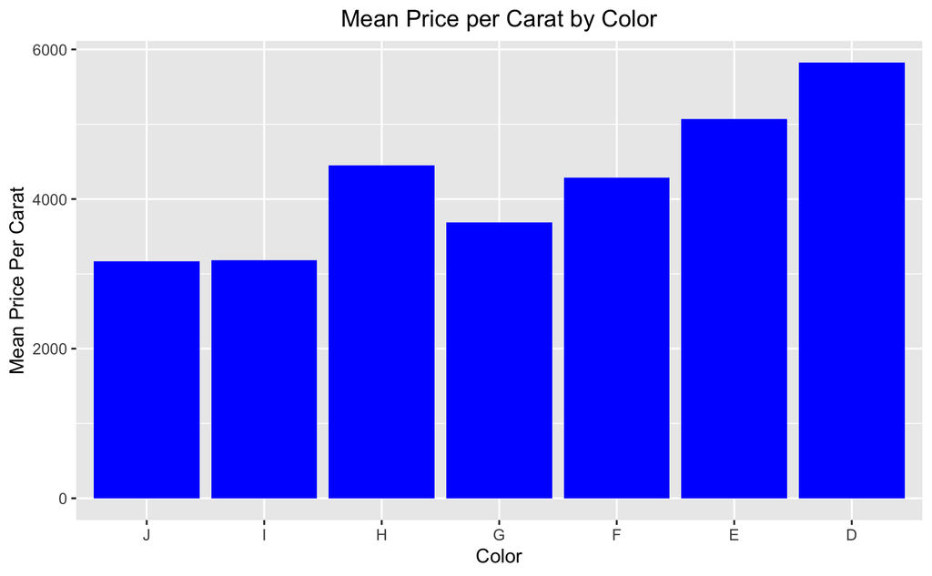

```r
ggplot(ColorVSPricePerCarat, aes(x=color, y=meanPrice))+
  geom_bar(stat="identity", fill = "blue")+
  theme(plot.title = element_text(hjust = .5))+
  labs(title = "Mean Price per Carat by Color",
       x = "Color",
       y = "Mean Price Per Carat")
```

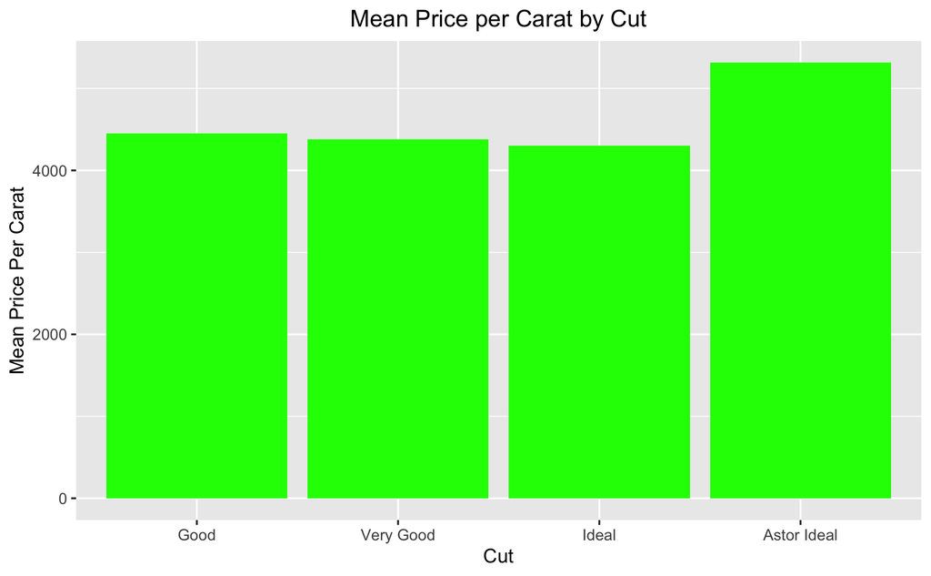

```r
ggplot(CutVSPricePerCarat, aes(x=cut, y=meanPrice))+
  geom_bar(stat="identity", fill = "green")+
  theme(plot.title = element_text(hjust = .5))+
  labs(title = "Mean Price per Carat by Cut",
       x = "Cut",
       y = "Mean Price Per Carat")
```

#looking at some outliers

```r
diamonds%>%
  filter(clarity == "FL")
```

| carat | clarity | color | cut | price | PricePerCarat |
| --- | --- | --- | --- | --- | --- |
| 5.22 | FL | D | Very Good | 355403 | 68084.866 |
| 0.29 | FL | D | Ideal | 1072 | 3696.552 |
| 1.40 | FL | F | Very Good | 13733 | 9809.286 |

```r
diamonds%>%
  filter(cut == "Ideal")
```

| carat | clarity | color | cut | price | PricePerCarat |
| --- | --- | --- | --- | --- | --- |
| 0.61 | VS2 | G | Ideal | 1947 | 3191.803 |
| 0.40 | VVS1 | J | Ideal | 684 | 1710.000 |
| 1.76 | VS1 | D | Ideal | 24451 | 13892.614 |
| 0.30 | VS2 | J | Ideal | 369 | 1230.000 |
| 0.30 | SI1 | F | Ideal | 563 | 1876.667 |
| 0.40 | VVS2 | F | Ideal | 859 | 2147.500 |
| 0.50 | VVS2 | I | Ideal | 1315 | 2630.000 |
| 0.32 | VS1 | H | Ideal | 671 | 2096.875 |
| 0.30 | VS1 | I | Ideal | 583 | 1943.333 |
| 0.31 | SI1 | I | Ideal | 427 | 1377.419 |

[output cut: 729 more lines]

```r
diamonds%>%
  filter(color == "H")
```

| carat | clarity | color | cut | price | PricePerCarat |
| --- | --- | --- | --- | --- | --- |
| 0.40 | VS2 | H | Very Good | 605 | 1512.500 |
| 1.01 | VS1 | H | Very Good | 6079 | 6018.812 |
| 0.32 | VS1 | H | Ideal | 671 | 2096.875 |
| 0.50 | VVS2 | H | Ideal | 1590 | 3180.000 |
| 0.30 | SI2 | H | Ideal | 408 | 1360.000 |
| 0.31 | VVS1 | H | Ideal | 676 | 2180.645 |
| 1.70 | VS1 | H | Ideal | 13537 | 7962.941 |
| 0.60 | VS2 | H | Ideal | 2212 | 3686.667 |
| 0.55 | VS1 | H | Ideal | 1601 | 2910.909 |
| 0.51 | SI2 | H | Ideal | 1139 | 2233.333 |

[output cut: 138 more lines]

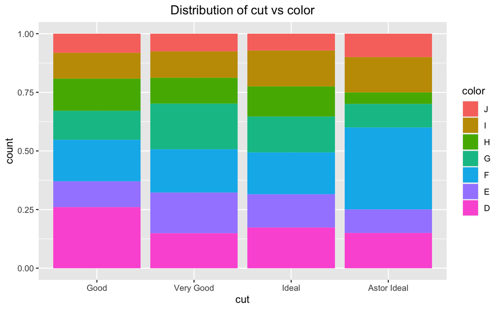

```r
ggplot(diamonds, aes(x=cut,fill=color))+
  geom_bar(position='fill')+
  theme(axis.text.x = element_text(),
        plot.title = element_text(hjust = 0.5))+
  labs(title="Distribution of cut vs color")
```

#Other than Astor Ideal (which only has 20 datapoints), good color seems to decrease as cut gets better. This corrlation could be a factor in why cut does not seem to correlate as much with price/carat.